# Data Exploration For Speed Dating

DuckieNukeEm

June 16, 2016

## R Markdown

GOOD MARROW PEOPLE OF THE DATING WORlD

This is my first crack at trying one of these, so this will be rough. But please do not hestiatet to provided constructive cristism for this.

Anyways, the data set, Speed Dating Data.csv, comes from Kaggle website and can be access via the following link, https://www.kaggle.com/annavictoria/speed-dating-experiment/downloads/Speed%20Dating%20Data.csv.zip

# Value of what people look for

Each person was asked at the start of the session what they are looking for. They were alloted 100pt and could distriubte it among 6 features. Waves 6~9 were given a 10 pt scale each, but the researchers converted into 100pt for us (THANKS GUYS :))

What are you Looking for in a date

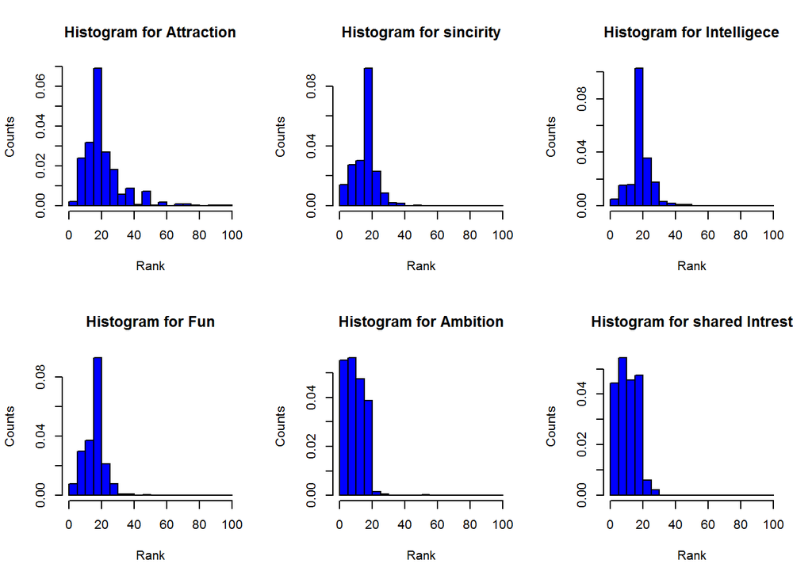

People are shallow and clearly rank Looks higher then intelligence, looks like Sincirity and Fun are tied for 3, and nobody gives a crap about shared intrest and ambitions. Shallow bastards!

So how do the lads vs Ladies stack up?

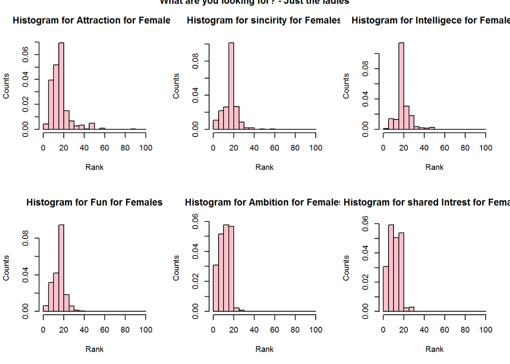

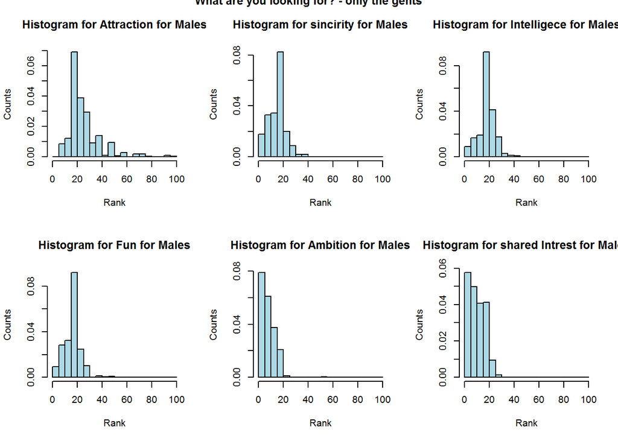

Shit I already knew, guys care more about looks than ladies do, while ladies have a slightly higher intrest in ambition and shared intrest. Ambition, that’s a curious one, why would they be diffrent? OH WELL

## What do you think your date is looking for?

Intresting stuff so far, so the participants were also asked to rank what their date was looking for

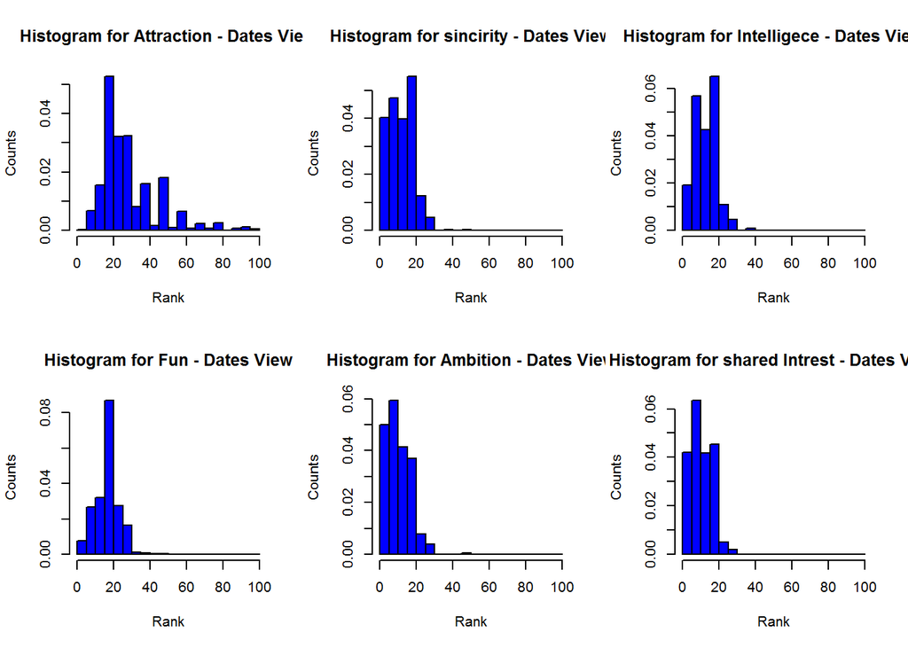

looks like the same story as previous

So how do the lads vs Ladies stack up?

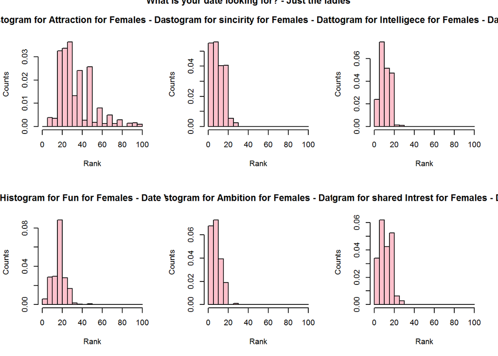

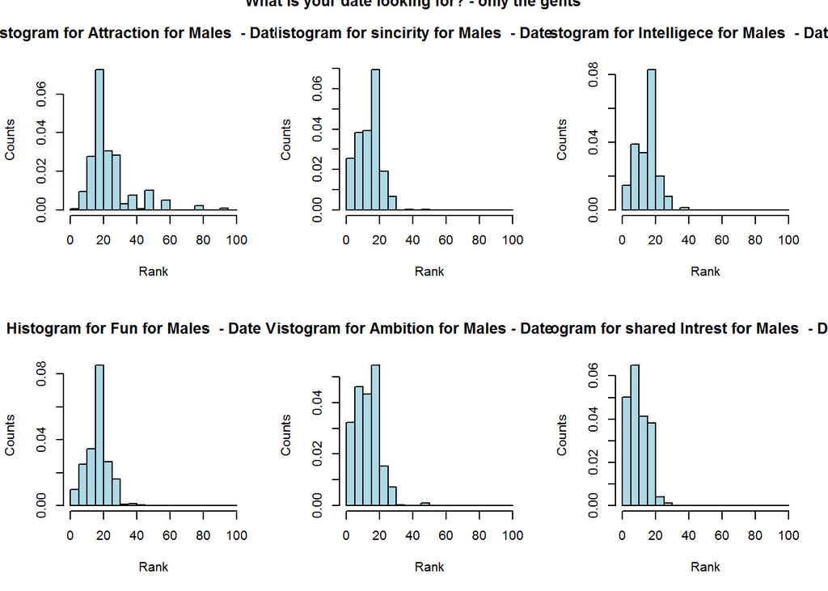

OOOO, intresting, so the gals think the guys are shallow and really only care about looks.